# DATA 605 Final project

Gr Living Area is a variable with a right skew

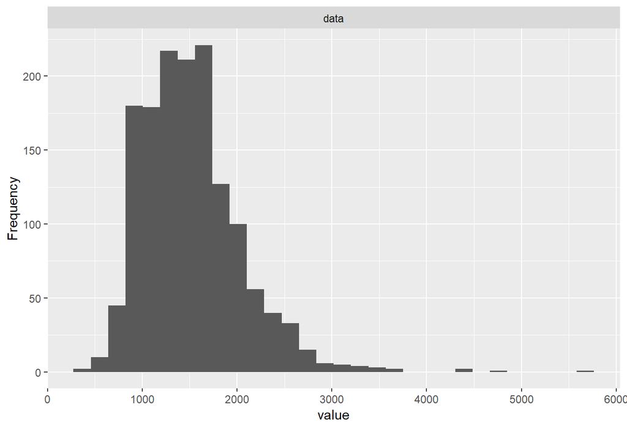

```r
plot_histogram(trainc$GrLivArea);
```

```r
summary(trainc$GrLivArea)
```

```
##    Min. 1st Qu.  Median    Mean 3rd Qu.    Max.
##     334    1130    1464    1515    1777    5642
```

Gr Living Area does not have a minimum of zero, therefore we do not need to shift the variable.

Then load the MASS package and run fitdistr to fit an exponential probability density function. (See https://stat.ethz.ch/R-manual/R-devel/library/MASS/html/fitdistr.html ). Find the optimal value of Î» for this distribution, and then take 1000 samples from this exponential distribution using this value (e.g., rexp(1000, Î»)). Plot a histogram and compare it with a histogram of your original variable.

```r
library(MASS)

dist<-fitdistr(trainc$GrLivArea, densfun = 'exponential')
lamda <- dist$estimate
exp_distibution <- rexp(1000, lamda)

summary(exp_distibution);
```

```
##      Min.   1st Qu.    Median      Mean   3rd Qu.      Max.
##     1.486   452.588  1025.358  1482.973  2087.005 10081.691
```

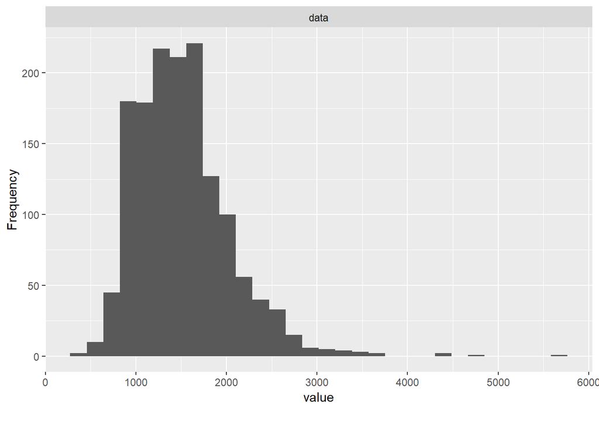

```r
plot_histogram(trainc$GrLivArea);
```

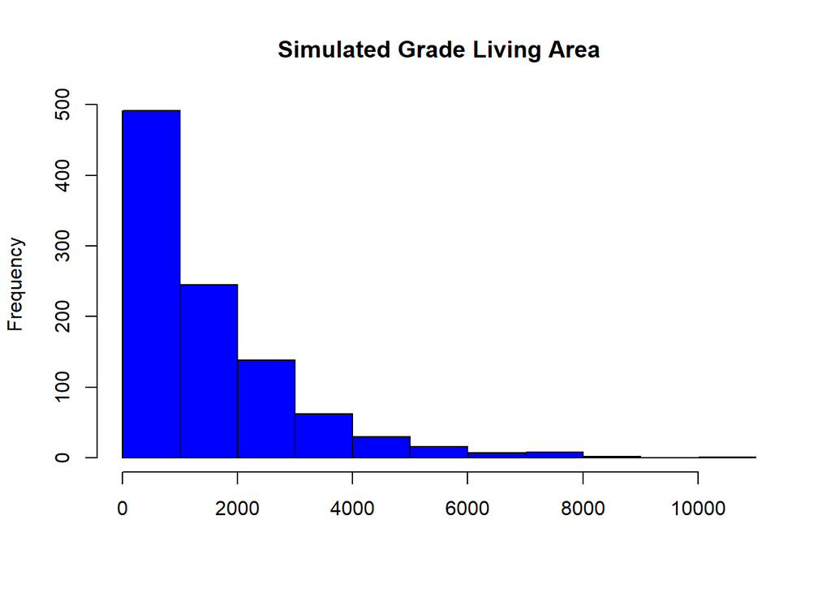

```r
hist(exp_distibution, main = "Simulated Grade Living Area", xlab="", col = "blue")
```

Using the exponential pdf, find the 5th and 95th percentiles using the cumulative distribution function (CDF).

```r
quantile(exp_distibution, c(.05, .95))
```

```
##         5%        95%
##   58.66712 4350.01900
```

Also generate a 95% confidence interval from the empirical data, assuming normality.

```r
library(Rmisc)
CI(trainc$GrLivArea, ci=0.95)
```

```
##    upper     mean    lower
## 1542.440 1515.464 1488.487
```

Finally, provide the empirical 5th percentile and 95th percentile of the data. Discuss.

```r
quantile(trainc$GrLivArea, c(.05, .95))
```

```
##     5%    95%
##  848.0 2466.1
```

*10 points.* Modeling. Build some type of multiple regression model and submit your model to the competition board. Provide your complete model summary and results with analysis. Report your Kaggle.com user name and score.

When it comes to modeling, there are numerous things that can be done with some more involved than others. I could do PCA decomposition to reduce the dimension of the data. I could also create multiple dummy variables with a degrees of freedom trade off. For the sake of this course, I will keep the model simple and limit them to variables that had decent correlation with Sales Price.

Lets see how close to the normal distribution our response variable is

```r
library(ggpubr)
```

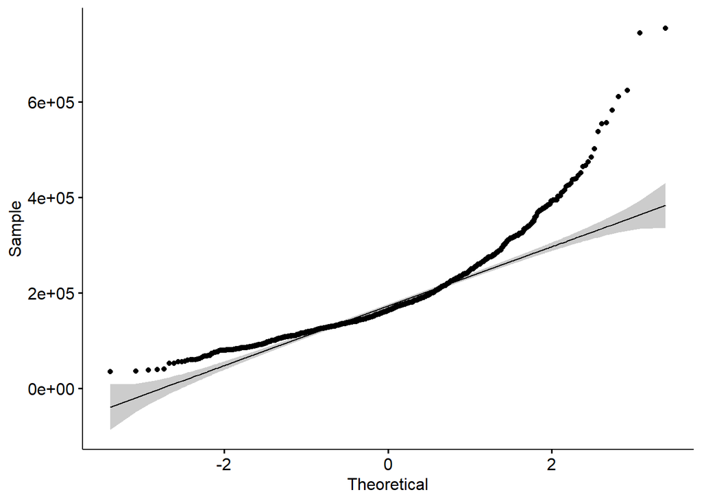

```r
ggqqplot(trainc$SalePrice);
```

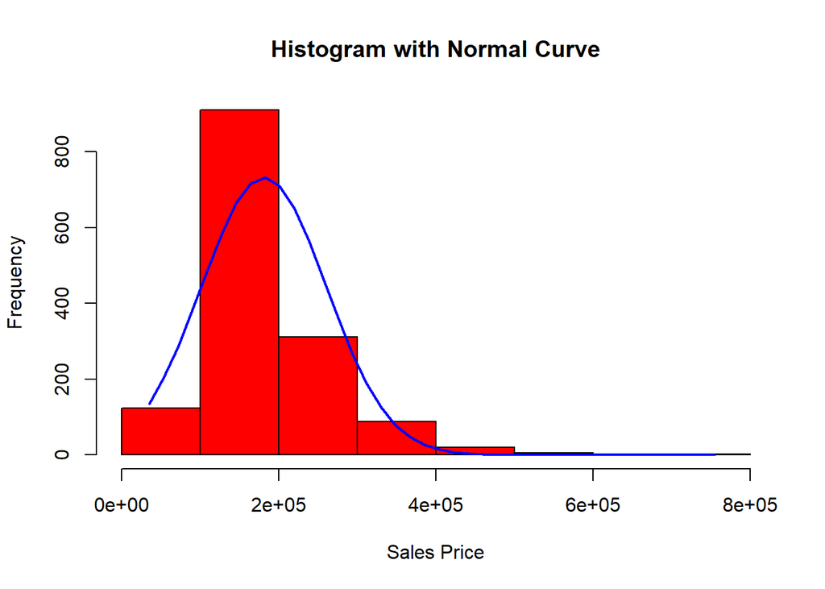

```r
x <- trainc$SalePrice
h<-hist(x, breaks=10, col="red", xlab="Sales Price",
    main="Histogram with Normal Curve")
xfit<-seq(min(x),max(x),length=40)
yfit<-dnorm(xfit,mean=mean(x),sd=sd(x))
yfit <- yfit*diff(h$mids[1:2])*length(x)
lines(xfit, yfit, col="blue", lwd=2)
```

We examined a heat map based off the correlation matrix. We can use that to our advantage. We can actually systematically go through a process that can identify what predictors have significant correlations with the response variables.

```r
cor(trainc[-37], trainc$SalePrice)
```

```
##                      [,1]
## MSSubClass    -0.08428414
## LotFrontage            NA
## LotArea        0.26384335
## OverallQual    0.79098160
## OverallCond   -0.07785589
## YearBuilt      0.52289733
## YearRemodAdd   0.50710097
## MasVnrArea             NA
## BsmtFinSF1     0.38641981
## BsmtFinSF2    -0.01137812
## BsmtUnfSF      0.21447911
## TotalBsmtSF    0.61358055
## X1stFlrSF      0.60585218
## X2ndFlrSF      0.31933380
## LowQualFinSF  -0.02560613
## GrLivArea      0.70862448
## BsmtFullBath   0.22712223
## BsmtHalfBath  -0.01684415
## FullBath       0.56066376
## HalfBath       0.28410768
## BedroomAbvGr   0.16821315
## KitchenAbvGr  -0.13590737
## TotRmsAbvGrd   0.53372316
## Fireplaces     0.46692884
## GarageYrBlt            NA
## GarageCars     0.64040920
## GarageArea     0.62343144
## WoodDeckSF     0.32441344
## OpenPorchSF    0.31585623
## EnclosedPorch -0.12857796
## X3SsnPorch     0.04458367
## ScreenPorch    0.11144657
## PoolArea       0.09240355
## MiscVal       -0.02118958
## MoSold         0.04643225
## YrSold        -0.02892259
```

We will take variables with strong positive correlations greater than .5. Using backward elimination technique to arrive at the optimal features to be included to our model.

```r
mod <- lm(SalePrice~GarageArea+GarageCars+TotRmsAbvGrd+FullBath+GrLivArea+X1stFlrSF+TotalBsmtSF+YearRemodAdd+YearBuilt+OverallQual, data=trainc)

summary(mod)
```

```
##
## Call:
## lm(formula = SalePrice ~ GarageArea + GarageCars + TotRmsAbvGrd +
##     FullBath + GrLivArea + X1stFlrSF + TotalBsmtSF + YearRemodAdd +
##     YearBuilt + OverallQual, data = trainc)
##
## Residuals:
##     Min      1Q  Median      3Q     Max
## -489958  -19316   -1948   16020  290558
##
## Coefficients:
##                Estimate Std. Error t value Pr(>|t|)
## (Intercept)  -1.186e+06  1.291e+05  -9.187  < 2e-16 ***
## GarageArea    1.495e+01  1.031e+01   1.450 0.147384
## GarageCars    1.042e+04  3.044e+03   3.422 0.000639 ***
## TotRmsAbvGrd  3.310e+01  1.119e+03   0.030 0.976404
## FullBath     -6.791e+03  2.682e+03  -2.532 0.011457 *
## GrLivArea     5.130e+01  4.233e+00  12.119  < 2e-16 ***
## X1stFlrSF     1.417e+01  4.930e+00   2.875 0.004097 **
## TotalBsmtSF   1.986e+01  4.295e+00   4.625 4.09e-06 ***
## YearRemodAdd  2.965e+02  6.363e+01   4.659 3.47e-06 ***
## YearBuilt     2.682e+02  5.035e+01   5.328 1.15e-07 ***
## OverallQual   1.960e+04  1.190e+03  16.472  < 2e-16 ***
## ---
## Signif. codes:  0 '***' 0.001 '**' 0.01 '*' 0.05 '.' 0.1 ' ' 1
##
## Residual standard error: 37920 on 1449 degrees of freedom
## Multiple R-squared:  0.7737, Adjusted R-squared:  0.7721
## F-statistic: 495.4 on 10 and 1449 DF,  p-value: < 2.2e-16
```

Garage area and Total Rooms Above grade do not appear to be significant as p-value is more than 0.05 hence we can remove this variable,and adjusted R squared value of .77 meaning, 77% of the variability in the data is accounted for.

Remove non significant predictors and re-fit model

```r
mod <- lm(SalePrice~GarageCars+FullBath+GrLivArea+X1stFlrSF+TotalBsmtSF+YearRemodAdd+YearBuilt+OverallQual, data=trainc)

summary(mod)
```

```
##
## Call:
## lm(formula = SalePrice ~ GarageCars + FullBath + GrLivArea +
##     X1stFlrSF + TotalBsmtSF + YearRemodAdd + YearBuilt + OverallQual,
##     data = trainc)
##
## Residuals:
##     Min      1Q  Median      3Q     Max
## -482525  -19191   -1801   16208  289639
##
## Coefficients:
##                Estimate Std. Error t value Pr(>|t|)
## (Intercept)  -1.188e+06  1.284e+05  -9.255  < 2e-16 ***
## GarageCars    1.395e+04  1.817e+03   7.680 2.92e-14 ***
## FullBath     -7.184e+03  2.644e+03  -2.717  0.00666 **
## GrLivArea     5.177e+01  3.097e+00  16.714  < 2e-16 ***
## X1stFlrSF     1.465e+01  4.919e+00   2.979  0.00294 **
## TotalBsmtSF   2.039e+01  4.269e+00   4.775 1.98e-06 ***
## YearRemodAdd  2.957e+02  6.362e+01   4.649 3.64e-06 ***
## YearBuilt     2.699e+02  5.017e+01   5.380 8.69e-08 ***
## OverallQual   1.959e+04  1.188e+03  16.486  < 2e-16 ***
## ---
## Signif. codes:  0 '***' 0.001 '**' 0.01 '*' 0.05 '.' 0.1 ' ' 1
##
## Residual standard error: 37920 on 1451 degrees of freedom
## Multiple R-squared:  0.7734, Adjusted R-squared:  0.7721
## F-statistic: 618.9 on 8 and 1451 DF,  p-value: < 2.2e-16
```

We still retain almost identical adjusted r square with fewer predictors.

Diagnostics

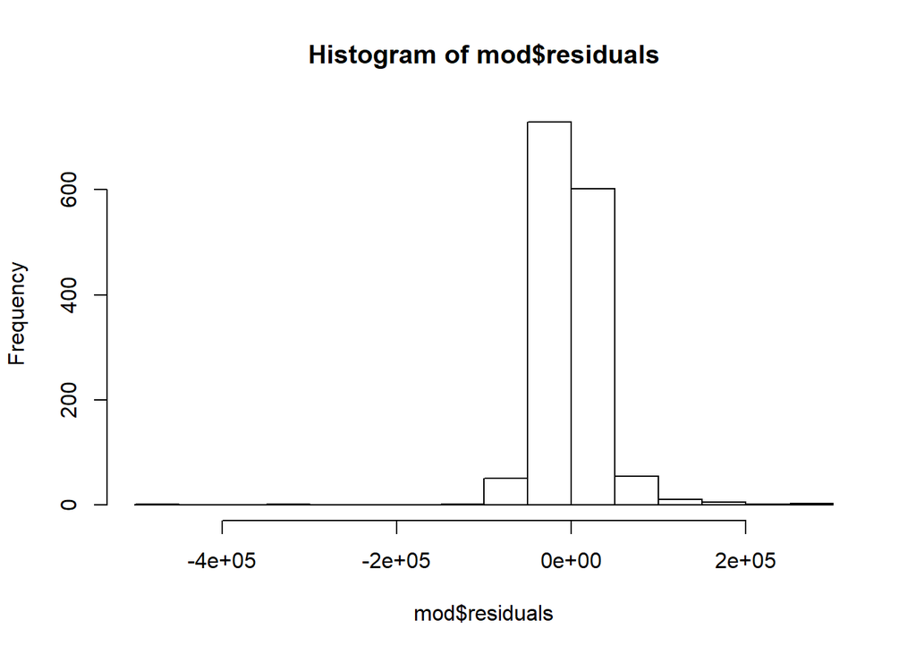

```r
hist(mod$residuals);
```

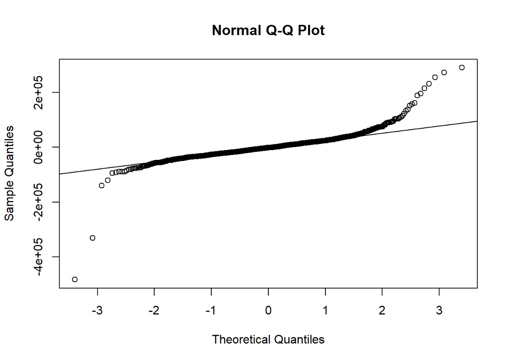

```r
qqnorm(mod$residuals);
qqline(mod$residuals)
```

The residuals seem to follow a close to normal distribution. We need to check constant variance.

```r
library('olsrr')
olsrr::ols_test_breusch_pagan(mod)
```

```
##
##  Breusch Pagan Test for Heteroskedasticity
##  -----------------------------------------
##  Ho: the variance is constant
##  Ha: the variance is not constant
##
##                 Data
##  -------------------------------------
##  Response : SalePrice
##  Variables: fitted values of SalePrice
##
##         Test Summary
##  ----------------------------
##  DF            =    1
##  Chi2          =    2921.5080
##  Prob > Chi2   =    0.0000
```

A small p value in the Breusch Pagan Test for Heteroskedasticity indicates strong evidence against the null value. We can say that constant variance is not met. Let us check visually.

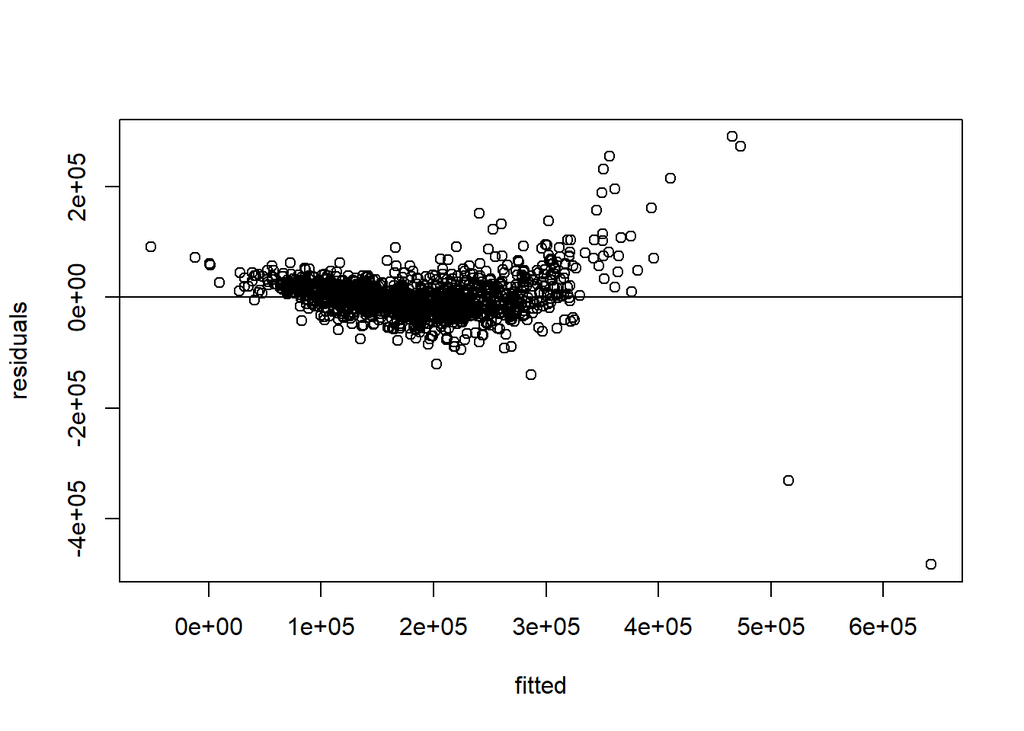

```r
plot(fitted(mod), residuals(mod), xlab="fitted", ylab="residuals")
abline(h=0);
```

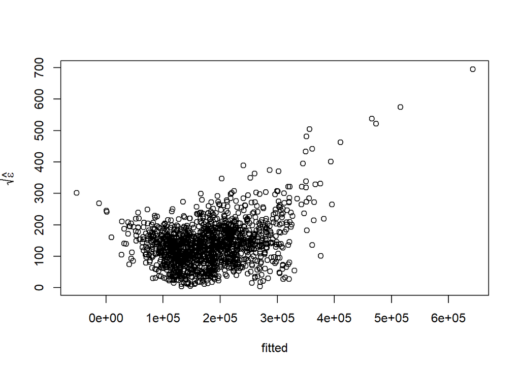

```r
plot(fitted(mod), sqrt(abs(residuals(mod))), xlab="fitted", ylab=expression(sqrt(hat(epsilon))))
```

If we look at the residuals, we can see a parabolic shape indicating that some transform needs to be done on the response variable. If we look at the square root of the residuals, the parabolic pattern becomes much more prominant.

We can apply the Box-Cox transform. This worlflow is highlighted in detail in Julian Farayws linear model in r book.

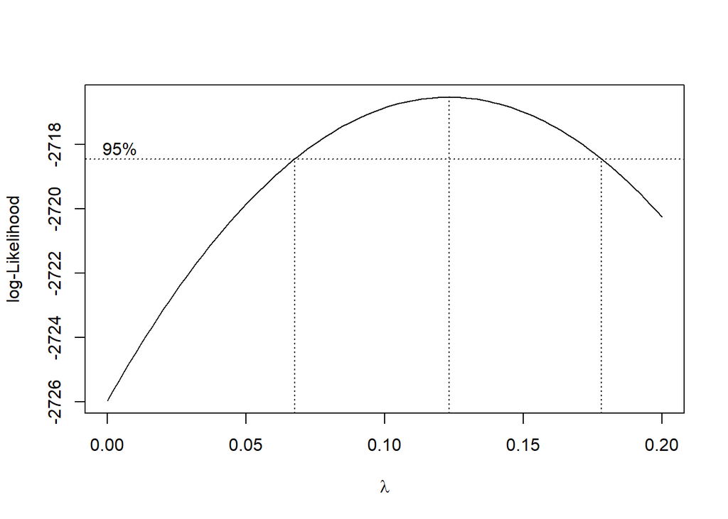

```r
library(MASS)

boxcox(mod, plotit=T, lambda=seq(0, 0.2, by=0.01))
```

According to the transform, the max log-likelihood happens around -2700. We can estimate a parameter lambda by using the center line bounded by the interval roughly (0.07, 0.17). It looks like our power transform is going to be 0.13

```r
traind<-trainc

mod2 <- lm(SalePrice^(0.13)~GarageCars+FullBath+GrLivArea+X1stFlrSF+TotalBsmtSF+YearRemodAdd+YearBuilt+OverallQual, data=trainc)

summary(mod2)
```

```
##
## Call:
## lm(formula = SalePrice^(0.13) ~ GarageCars + FullBath + GrLivArea +
##     X1stFlrSF + TotalBsmtSF + YearRemodAdd + YearBuilt + OverallQual,
##     data = trainc)
##
## Residuals:
##      Min       1Q   Median       3Q      Max
## -1.38745 -0.04679  0.00302  0.05812  0.34836
##
## Coefficients:
##                Estimate Std. Error t value Pr(>|t|)
## (Intercept)  -8.760e-01  3.544e-01  -2.471   0.0136 *
## GarageCars    5.209e-02  5.016e-03  10.383  < 2e-16 ***
## FullBath     -1.291e-02  7.301e-03  -1.769   0.0771 .
## GrLivArea     1.500e-04  8.552e-06  17.542  < 2e-16 ***
## X1stFlrSF     3.827e-05  1.358e-05   2.818   0.0049 **
## TotalBsmtSF   5.718e-05  1.179e-05   4.850 1.36e-06 ***
## YearRemodAdd  1.331e-03  1.757e-04   7.579 6.19e-14 ***
## YearBuilt     1.139e-03  1.385e-04   8.219 4.50e-16 ***
## OverallQual   5.982e-02  3.281e-03  18.234  < 2e-16 ***
## ---
## Signif. codes:  0 '***' 0.001 '**' 0.01 '*' 0.05 '.' 0.1 ' ' 1
##
## Residual standard error: 0.1047 on 1451 degrees of freedom
## Multiple R-squared:  0.8246, Adjusted R-squared:  0.8236
## F-statistic: 852.4 on 8 and 1451 DF,  p-value: < 2.2e-16
```

Residual standard error has decreased significantly while out adjusted r square has increased from .77 to .82.

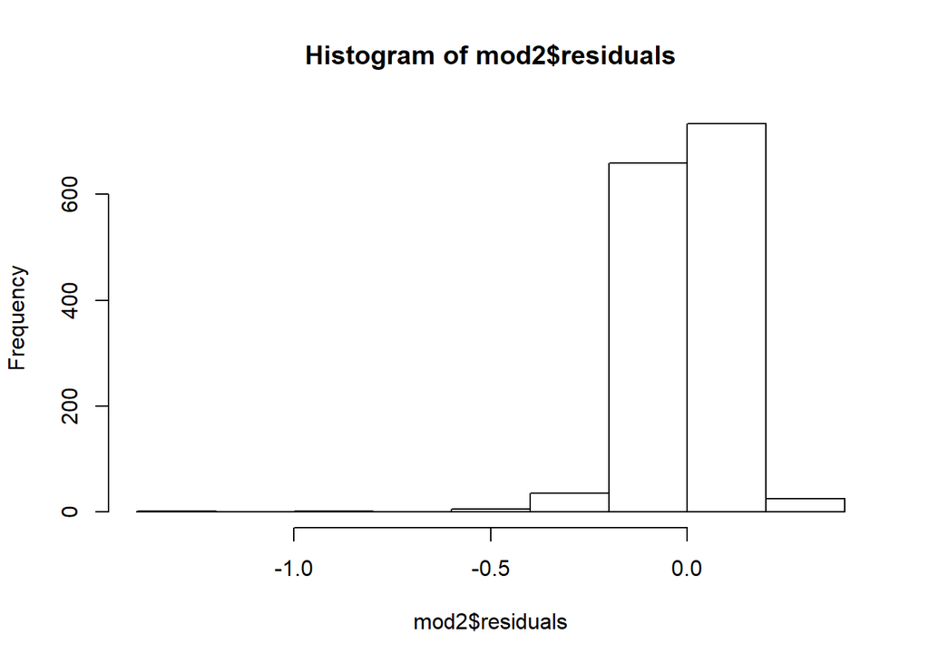

```r
hist(mod2$residuals);
```

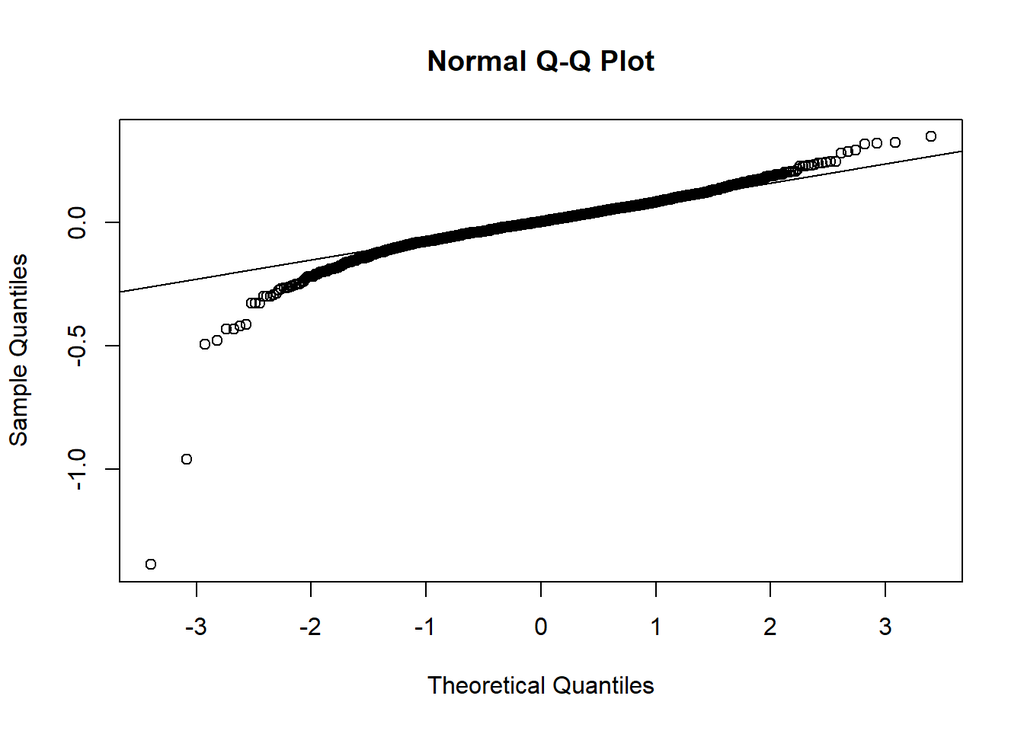

```r
qqnorm(mod2$residuals);
qqline(mod2$residuals)
```

There is a slight skew introduced into the residuals but it does not appear to be much. Lets visually check constant variance.

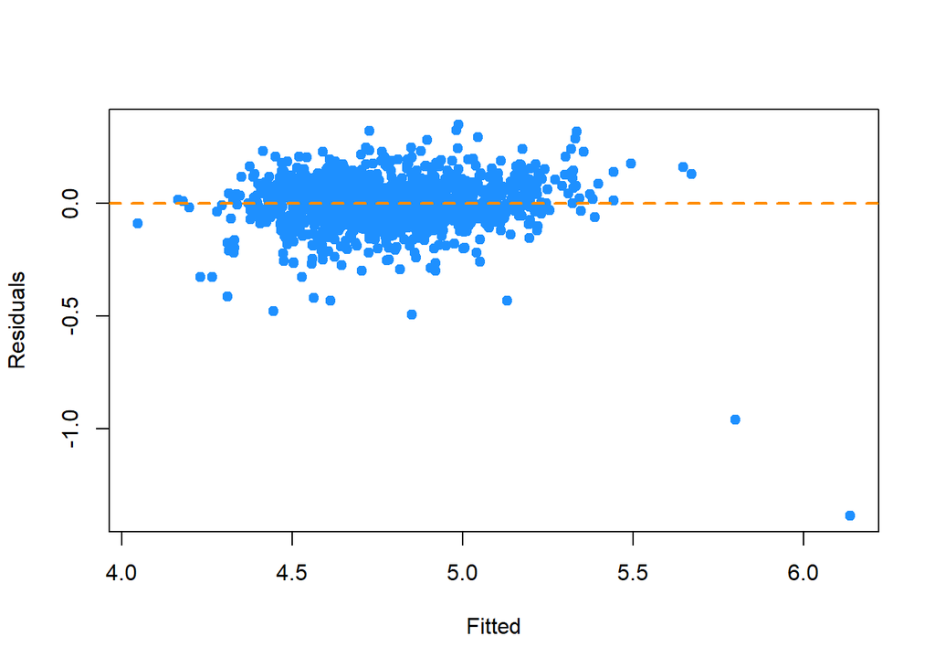

```r
plot(fitted(mod2), resid(mod2), col = "dodgerblue",
     pch = 20, cex = 1.5, xlab = "Fitted", ylab = "Residuals")
abline(h = 0, lty = 2, col = "darkorange", lwd = 2)
```

Lets examine outliers on a top level

```r
library(car)
outlierTest(mod2)
```

```
##        rstudent unadjusted p-value Bonferonni p
## 1299 -15.538912         1.7562e-50   2.5640e-47
## 524   -9.634839         2.4441e-21   3.5683e-18
## 633   -4.748411         2.2531e-06   3.2895e-03
## 31    -4.617930         4.2190e-06   6.1597e-03
## 1325  -4.171794         3.2015e-05   4.6742e-02
```

Can we reduce our predictors even more by using variance inflation numbers?

```r
vif(mod2)
```

```
##   GarageCars     FullBath    GrLivArea    X1stFlrSF  TotalBsmtSF
##     1.869688     2.152343     2.687048     3.668313     3.558638
## YearRemodAdd    YearBuilt  OverallQual
##     1.750023     2.329177     2.738752
```

VIF numbers indicate that we do not need to remove additional predictors since there is no VIF number that is unsually large.

Before we conclude modeling, lets examine all possible permutations of predictors and see their performance based on KPI such as adjusted r square and mallows CP.

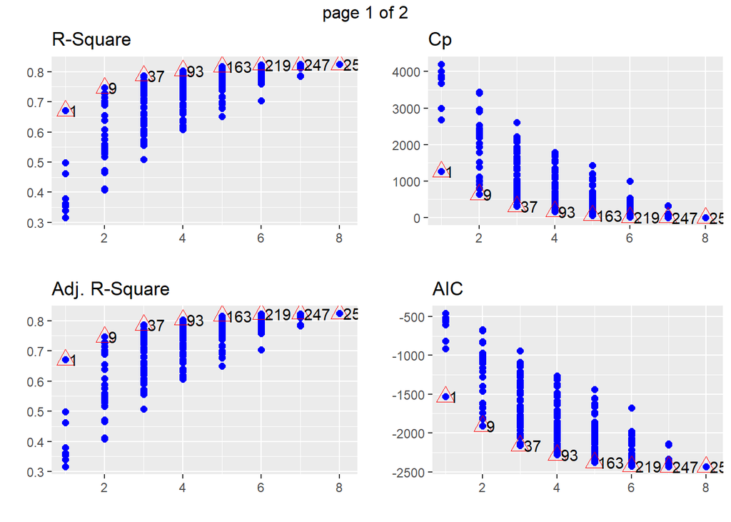

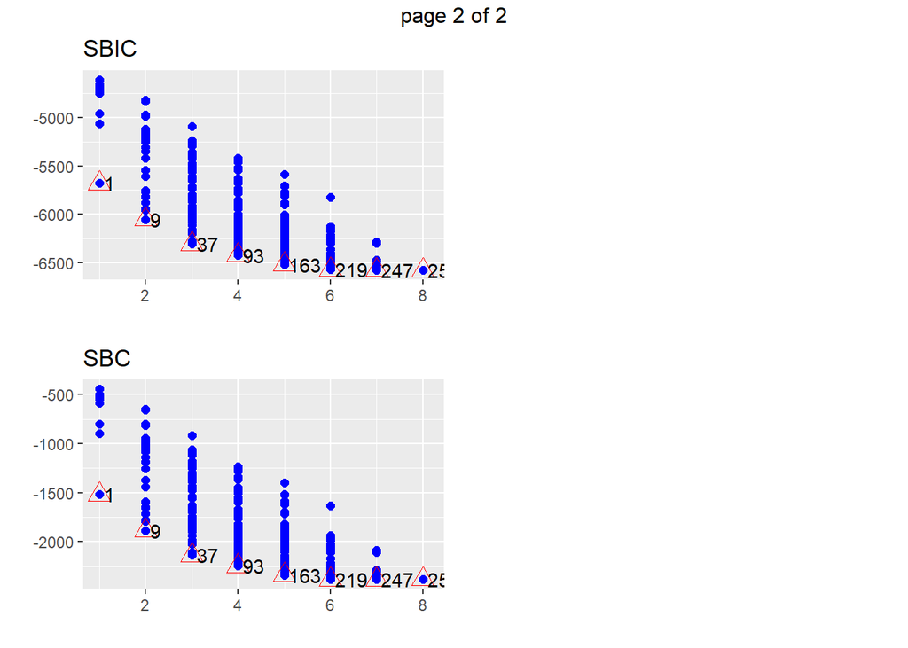

```r
k<-ols_step_all_possible(mod2)
plot(k)
```

From a top level, using all 8 predictors yields the better adjusted r square and reduced the AIC.

Feature selection at a more detailed level

```r
h<-ols_step_best_subset(mod2)
h
```

```
##                                        Best Subsets Regression
## -----------------------------------------------------------------------------------------------------
## Model Index    Predictors
## -----------------------------------------------------------------------------------------------------
##      1         OverallQual
##      2         GrLivArea OverallQual
##      3         GrLivArea YearBuilt OverallQual
##      4         GarageCars GrLivArea YearBuilt OverallQual
##      5         GarageCars GrLivArea TotalBsmtSF YearBuilt OverallQual
##      6         GarageCars GrLivArea TotalBsmtSF YearRemodAdd YearBuilt OverallQual
##      7         GarageCars GrLivArea X1stFlrSF TotalBsmtSF YearRemodAdd YearBuilt OverallQual
##      8         GarageCars FullBath GrLivArea X1stFlrSF TotalBsmtSF YearRemodAdd YearBuilt OverallQual
## -----------------------------------------------------------------------------------------------------
##
##                                                        Subsets Regression Summary
## ----------------------------------------------------------------------------------------------------------------------------------------
##                        Adj.        Pred
## Model    R-Square    R-Square    R-Square      C(p)          AIC           SBIC          SBC         MSEP      FPE       HSP       APC
## ----------------------------------------------------------------------------------------------------------------------------------------
##   1        0.6714      0.6712      0.6704    1261.4740    -1532.4749    -5678.0546    -1516.6163    0.0205    0.0205    0.0000    0.3295
##   2        0.7464      0.7461      0.7435     643.2617    -1908.7174    -6054.0257    -1887.5727    0.0158    0.0158    0.0000    0.2546
##   3        0.7871      0.7867      0.7839     308.7680    -2162.0458    -6306.7712    -2135.6149    0.0133    0.0133    0.0000    0.2141
##   4        0.8037      0.8032      0.8003     173.3529    -2278.6801    -6423.0072    -2246.9630    0.0123    0.0123    0.0000    0.1976
##   5        0.8166      0.8160      0.8073      68.6192    -2375.9748    -6519.7261    -2338.9715    0.0115    0.0115    0.0000    0.1849
##   6        0.8233      0.8225      0.8137      15.6517    -2427.8729    -6571.1893    -2385.5834    0.0111    0.0111    0.0000    0.1784
##   7        0.8242      0.8233      0.8144      10.1290    -2433.4066    -6576.6425    -2385.8308    0.0110    0.0110    0.0000    0.1778
##   8        0.8246      0.8236      0.8134       9.0000    -2434.5516    -6577.7405    -2381.6897    0.0110    0.0110    0.0000    0.1776
## ----------------------------------------------------------------------------------------------------------------------------------------
## AIC: Akaike Information Criteria
##  SBIC: Sawa's Bayesian Information Criteria
##  SBC: Schwarz Bayesian Criteria
##  MSEP: Estimated error of prediction, assuming multivariate normality
##  FPE: Final Prediction Error
##  HSP: Hocking's Sp
##  APC: Amemiya Prediction Criteria
```

It seems that model 4-8 are pretty close in adjusted r square but if any more predictors get removed, there is a sharp drop off.

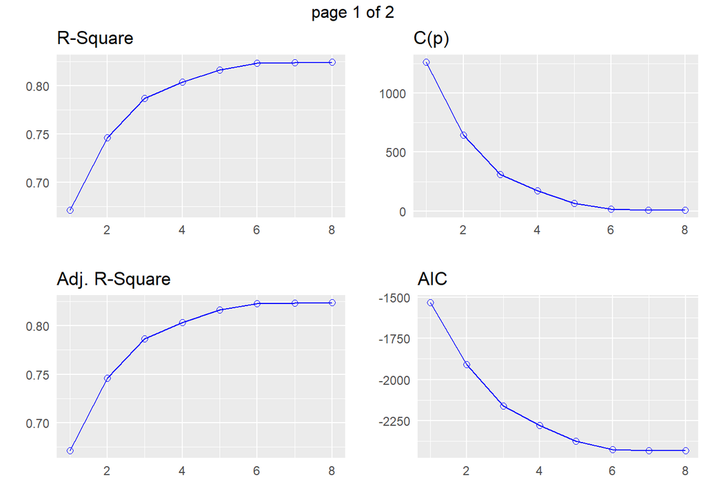

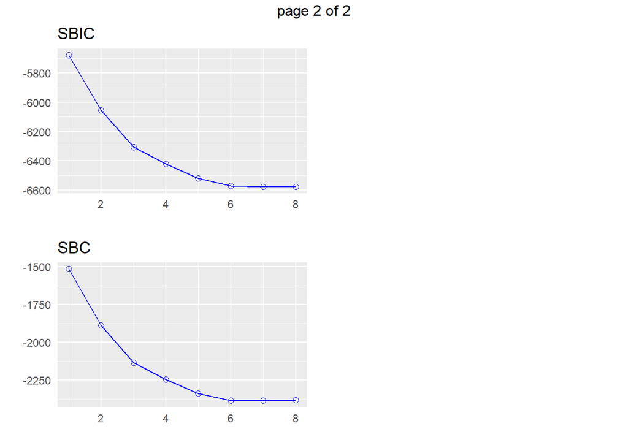

```r
plot(h)
```

It is easy to keep looking for methods to optimize the model. I would even go as far as saying that a GLM should be considered here but that is outside the scope of the class.

Lets apply to our test data and make some predictions

```r
test_results <- predict(mod2, test)

prediction <- data.frame(Id = test[,"Id"],  SalePrice = test_results)

prediction[prediction<0] <- 0

prediction <- replace(prediction,is.na(prediction),0)

prediction$SalePrice <- prediction$SalePrice^(1/.13)

head(test_results)
```

```
##        1        2        3        4        5        6
## 4.525119 4.684621 4.768366 4.825383 4.915384 4.806456
```

```r
write.csv(prediction, "SPpredictions.csv")
```

Kaggle results Number 5761, posted under vishal0229 : 1 submission score 0.47026

[figure not shown]